# Real Estate Project

```python
import pandas as pd

df = pd.read_csv("C:/Users/19169/Documents/New Folder/Books Dataset/usa_housing.csv")
print(df.head())
```

```
    Price  Bedrooms  Bathrooms  SquareFeet  YearBuilt  GarageSpaces  LotSize  \
0  221958         1        1.9        4827       1979             2     1.45
1  771155         2        2.0        1035       1987             2     1.75
2  231932         1        3.0        2769       1982             1     1.46
3  465838         3        3.3        2708       1907             3     1.62
4  359178         4        3.4        1175       1994             2     0.74

   ZipCode  CrimeRate  SchoolRating
0    82240      48.60             5
1    74315      92.03             9
2    79249      52.08             3
3    80587      61.65             1
4    20756      15.66             4
```

```python
df.info()
```

```
<class 'pandas.core.frame.DataFrame'>
RangeIndex: 300 entries, 0 to 299
Data columns (total 10 columns):
 #   Column        Non-Null Count  Dtype
---  ------        --------------  -----
 0   Price         300 non-null    int64
 1   Bedrooms      300 non-null    int64
 2   Bathrooms     300 non-null    float64
 3   SquareFeet    300 non-null    int64
 4   YearBuilt     300 non-null    int64
 5   GarageSpaces  300 non-null    int64
 6   LotSize       300 non-null    float64
 7   ZipCode       300 non-null    int64
 8   CrimeRate     300 non-null    float64
 9   SchoolRating  300 non-null    int64
dtypes: float64(3), int64(7)
memory usage: 23.6 KB
```

```python
df.drop_duplicates()
```

|  | Price | Bedrooms | Bathrooms | SquareFeet | YearBuilt | GarageSpaces | LotSize | ZipCode | CrimeRate | SchoolRating |
| --- | --- | --- | --- | --- | --- | --- | --- | --- | --- | --- |
| 0 | 221958 | 1 | 1.9 | 4827 | 1979 | 2 | 1.45 | 82240 | 48.60 | 5 |
| 1 | 771155 | 2 | 2.0 | 1035 | 1987 | 2 | 1.75 | 74315 | 92.03 | 9 |
| 2 | 231932 | 1 | 3.0 | 2769 | 1982 | 1 | 1.46 | 79249 | 52.08 | 3 |
| 3 | 465838 | 3 | 3.3 | 2708 | 1907 | 3 | 1.62 | 80587 | 61.65 | 1 |
| 4 | 359178 | 4 | 3.4 | 1175 | 1994 | 2 | 0.74 | 20756 | 15.66 | 4 |
| ... | ... | ... | ... | ... | ... | ... | ... | ... | ... | ... |
| 295 | 862002 | 4 | 2.8 | 1129 | 1944 | 0 | 1.80 | 35227 | 32.30 | 3 |
| 296 | 242483 | 3 | 2.4 | 4440 | 1988 | 2 | 0.46 | 15978 | 99.71 | 9 |
| 297 | 758271 | 2 | 2.2 | 4694 | 1952 | 2 | 0.71 | 97527 | 97.98 | 7 |
| 298 | 314835 | 5 | 2.0 | 4907 | 1941 | 3 | 0.53 | 27153 | 65.61 | 8 |
| 299 | 501896 | 5 | 3.8 | 2141 | 1999 | 0 | 0.77 | 69765 | 12.98 | 9 |

300 rows × 10 columns

```python
df = df.drop_duplicates(subset=['Price','Bedrooms','Bathrooms','SquareFeet','YearBuilt','GarageSpaces','LotSize','ZipCode','CrimeRate','SchoolRating'])
print(df)
```

```
      Price  Bedrooms  Bathrooms  SquareFeet  YearBuilt  GarageSpaces  \
0    221958         1        1.9        4827       1979             2
1    771155         2        2.0        1035       1987             2
2    231932         1        3.0        2769       1982             1
3    465838         3        3.3        2708       1907             3
4    359178         4        3.4        1175       1994             2
..      ...       ...        ...         ...        ...           ...
295  862002         4        2.8        1129       1944             0
296  242483         3        2.4        4440       1988             2
297  758271         2        2.2        4694       1952             2
298  314835         5        2.0        4907       1941             3
299  501896         5        3.8        2141       1999             0

     LotSize  ZipCode  CrimeRate  SchoolRating
0       1.45    82240      48.60             5
1       1.75    74315      92.03             9
2       1.46    79249      52.08             3
3       1.62    80587      61.65             1
4       0.74    20756      15.66             4
..       ...      ...        ...           ...
295     1.80    35227      32.30             3
296     0.46    15978      99.71             9
297     0.71    97527      97.98             7
298     0.53    27153      65.61             8
299     0.77    69765      12.98             9

[300 rows x 10 columns]
```

```python
df.dropna()
```

|  | Price | Bedrooms | Bathrooms | SquareFeet | YearBuilt | GarageSpaces | LotSize | ZipCode | CrimeRate | SchoolRating |
| --- | --- | --- | --- | --- | --- | --- | --- | --- | --- | --- |
| 0 | 221958 | 1 | 1.9 | 4827 | 1979 | 2 | 1.45 | 82240 | 48.60 | 5 |
| 1 | 771155 | 2 | 2.0 | 1035 | 1987 | 2 | 1.75 | 74315 | 92.03 | 9 |
| 2 | 231932 | 1 | 3.0 | 2769 | 1982 | 1 | 1.46 | 79249 | 52.08 | 3 |
| 3 | 465838 | 3 | 3.3 | 2708 | 1907 | 3 | 1.62 | 80587 | 61.65 | 1 |
| 4 | 359178 | 4 | 3.4 | 1175 | 1994 | 2 | 0.74 | 20756 | 15.66 | 4 |
| ... | ... | ... | ... | ... | ... | ... | ... | ... | ... | ... |
| 295 | 862002 | 4 | 2.8 | 1129 | 1944 | 0 | 1.80 | 35227 | 32.30 | 3 |
| 296 | 242483 | 3 | 2.4 | 4440 | 1988 | 2 | 0.46 | 15978 | 99.71 | 9 |
| 297 | 758271 | 2 | 2.2 | 4694 | 1952 | 2 | 0.71 | 97527 | 97.98 | 7 |
| 298 | 314835 | 5 | 2.0 | 4907 | 1941 | 3 | 0.53 | 27153 | 65.61 | 8 |
| 299 | 501896 | 5 | 3.8 | 2141 | 1999 | 0 | 0.77 | 69765 | 12.98 | 9 |

300 rows × 10 columns

```python
df.describe()
```

|  | Price | Bedrooms | Bathrooms | SquareFeet | YearBuilt | GarageSpaces | LotSize | ZipCode | CrimeRate | SchoolRating |
| --- | --- | --- | --- | --- | --- | --- | --- | --- | --- | --- |
| count | 300.000000 | 300.000000 | 300.000000 | 300.00000 | 300.000000 | 300.000000 | 300.000000 | 300.000000 | 300.000000 | 300.000000 |
| mean | 522761.916667 | 2.966667 | 2.464000 | 3052.75000 | 1962.616667 | 1.513333 | 1.062200 | 54324.770000 | 49.324033 | 5.096667 |
| std | 256922.348275 | 1.451175 | 0.886184 | 1194.97144 | 36.005431 | 1.116832 | 0.543896 | 24718.938552 | 28.833220 | 2.674165 |
| min | 112666.000000 | 1.000000 | 1.000000 | 840.00000 | 1902.000000 | 0.000000 | 0.110000 | 10163.000000 | 0.190000 | 1.000000 |
| 25% | 299936.500000 | 2.000000 | 1.700000 | 2053.50000 | 1931.750000 | 1.000000 | 0.570000 | 34175.000000 | 22.547500 | 3.000000 |
| 50% | 505806.500000 | 3.000000 | 2.400000 | 3127.00000 | 1961.000000 | 1.000000 | 1.085000 | 54896.500000 | 49.970000 | 5.000000 |
| 75% | 744603.750000 | 4.000000 | 3.200000 | 4081.00000 | 1994.000000 | 3.000000 | 1.482500 | 74108.000000 | 74.402500 | 8.000000 |
| max | 999684.000000 | 5.000000 | 4.000000 | 4997.00000 | 2022.000000 | 3.000000 | 2.000000 | 99881.000000 | 99.710000 | 9.000000 |

```python
df.corr()
```

|  | Price | Bedrooms | Bathrooms | SquareFeet | YearBuilt | GarageSpaces | LotSize | ZipCode | CrimeRate | SchoolRating |
| --- | --- | --- | --- | --- | --- | --- | --- | --- | --- | --- |
| Price | 1.000000 | 0.018099 | 0.036418 | 0.043772 | 0.005021 | 0.008747 | -0.022611 | -0.018280 | 0.009642 | 0.024798 |
| Bedrooms | 0.018099 | 1.000000 | -0.043587 | -0.061484 | -0.029369 | -0.038933 | -0.045924 | 0.113818 | 0.009177 | 0.013761 |
| Bathrooms | 0.036418 | -0.043587 | 1.000000 | 0.014085 | -0.069268 | -0.007624 | -0.095377 | 0.038981 | 0.007045 | 0.059901 |
| SquareFeet | 0.043772 | -0.061484 | 0.014085 | 1.000000 | -0.000233 | 0.049112 | 0.009455 | -0.014022 | -0.042485 | 0.003732 |
| YearBuilt | 0.005021 | -0.029369 | -0.069268 | -0.000233 | 1.000000 | 0.088580 | -0.103685 | -0.033012 | -0.015365 | 0.004902 |
| GarageSpaces | 0.008747 | -0.038933 | -0.007624 | 0.049112 | 0.088580 | 1.000000 | 0.108032 | 0.005781 | -0.005727 | 0.034842 |
| LotSize | -0.022611 | -0.045924 | -0.095377 | 0.009455 | -0.103685 | 0.108032 | 1.000000 | 0.118551 | 0.030794 | -0.043491 |
| ZipCode | -0.018280 | 0.113818 | 0.038981 | -0.014022 | -0.033012 | 0.005781 | 0.118551 | 1.000000 | -0.008417 | -0.030294 |
| CrimeRate | 0.009642 | 0.009177 | 0.007045 | -0.042485 | -0.015365 | -0.005727 | 0.030794 | -0.008417 | 1.000000 | -0.016638 |
| SchoolRating | 0.024798 | 0.013761 | 0.059901 | 0.003732 | 0.004902 | 0.034842 | -0.043491 | -0.030294 | -0.016638 | 1.000000 |

```python
df.skew()
```

```
Price           0.191724
Bedrooms        0.012095
Bathrooms       0.113584
SquareFeet     -0.190702
YearBuilt      -0.044326
GarageSpaces    0.002614
LotSize        -0.037611
ZipCode         0.021299
CrimeRate       0.005177
SchoolRating    0.015256
dtype: float64
```

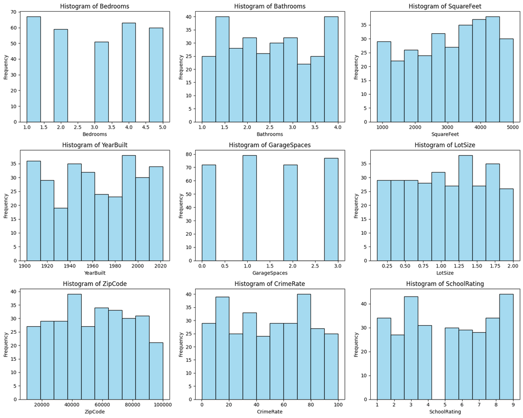

```python
import pandas as pd
import seaborn as sns
import matplotlib.pyplot as plt
import numpy as np
import math

# Sample DataFrame (replace this with your actual data loading)
data = df

# Set the figure size for the histograms
plt.figure(figsize=(18, 12))

# List of features and target (you can add/remove columns based on your dataset)
columns_to_plot = ['Bedrooms', 'Bathrooms','SquareFeet','YearBuilt','GarageSpaces', 'LotSize','ZipCode', 'CrimeRate', 'SchoolRating']
target = 'price'

# Dynamically calculate rows and columns
n = len(columns_to_plot)
cols = 3  # number of columns you want
rows = math.ceil(n / cols)

# Set figure size
plt.figure(figsize=(cols * 5, rows * 4))

# Plot each histogram
for i, col in enumerate(columns_to_plot):
    plt.subplot(rows, cols, i + 1)
    sns.histplot(data[col], bins=10, kde=False, color='skyblue')
    plt.title(f'Histogram of {col}')
    plt.xlabel(col)
    plt.ylabel('Frequency')

plt.tight_layout()
plt.show()
```

```python
df['HouseAge'] = 2025- df['YearBuilt']

print(df.head())
```

```
    Price  Bedrooms  Bathrooms  SquareFeet  YearBuilt  GarageSpaces  LotSize  \
0  221958         1        1.9        4827       1979             2     1.45
1  771155         2        2.0        1035       1987             2     1.75
2  231932         1        3.0        2769       1982             1     1.46
3  465838         3        3.3        2708       1907             3     1.62
4  359178         4        3.4        1175       1994             2     0.74

   ZipCode  CrimeRate  SchoolRating  HouseAge
0    82240      48.60             5        46
1    74315      92.03             9        38
2    79249      52.08             3        43
3    80587      61.65             1       118
4    20756      15.66             4        31
```

```python
print(df.head())
```

```
    Price  Bedrooms  Bathrooms  SquareFeet  YearBuilt  GarageSpaces  LotSize  \
0  221958         1        1.9        4827       1979             2     1.45
1  771155         2        2.0        1035       1987             2     1.75
2  231932         1        3.0        2769       1982             1     1.46
3  465838         3        3.3        2708       1907             3     1.62
4  359178         4        3.4        1175       1994             2     0.74

   ZipCode  CrimeRate  SchoolRating  HouseAge
0    82240      48.60             5        46
1    74315      92.03             9        38
2    79249      52.08             3        43
3    80587      61.65             1       118
4    20756      15.66             4        31
```

# DEtect Ouliers, For continous varibales, use IQR mthod , since they contain some skewness and are more robust to outliers.

```python
import pandas as pd

# Sample DataFrame (you can replace this with your actual data)
# df = pd.read_csv('your_file.csv')  # if you're using an actual file

# Define a function to calculate IQR and detect outliers
def detect_outliers_iqr(df, column_name):
    Q1 = df[column_name].quantile(0.25)
    Q3 = df[column_name].quantile(0.75)
    IQR = Q3 - Q1

    lower_bound = Q1 - 1.5 * IQR
    upper_bound = Q3 + 1.5 * IQR

    print(f"\nColumn: {column_name}")
    print(f"Lower Bound: {lower_bound}")
    print(f"Upper Bound: {upper_bound}")

    # Detect outliers
    outliers = df[(df[column_name] < lower_bound) | (df[column_name] > upper_bound)]
    return outliers

# List of columns to check
columns_to_check = ['Price', 'SquareFeet', 'LotSize', 'GarageSpaces']

# Loop through each column and detect outliers
for column in columns_to_check:
    outliers = detect_outliers_iqr(df, column)
    print(f"\nOutliers for {column}:")
    print(outliers)
```

```
Column: Price
Lower Bound: -367064.375
Upper Bound: 1411604.625

Outliers for Price:
Empty DataFrame
Columns: [Price, Bedrooms, Bathrooms, SquareFeet, YearBuilt, GarageSpaces, LotSize, ZipCode, CrimeRate, SchoolRating, HouseAge]
Index: []

Column: SquareFeet
Lower Bound: -987.75
Upper Bound: 7122.25

Outliers for SquareFeet:
Empty DataFrame
Columns: [Price, Bedrooms, Bathrooms, SquareFeet, YearBuilt, GarageSpaces, LotSize, ZipCode, CrimeRate, SchoolRating, HouseAge]
Index: []

Column: LotSize
Lower Bound: -0.79875
Upper Bound: 2.85125

Outliers for LotSize:
Empty DataFrame
Columns: [Price, Bedrooms, Bathrooms, SquareFeet, YearBuilt, GarageSpaces, LotSize, ZipCode, CrimeRate, SchoolRating, HouseAge]
Index: []

Column: GarageSpaces
Lower Bound: -2.0
Upper Bound: 6.0

Outliers for GarageSpaces:
Empty DataFrame
Columns: [Price, Bedrooms, Bathrooms, SquareFeet, YearBuilt, GarageSpaces, LotSize, ZipCode, CrimeRate, SchoolRating, HouseAge]
Index: []
```

```python
# calculate outliers in price

lower_bound = -0.79875
upper_bound = 2.85125

#filter outliers based on the IQR
LotSize_outliers = df[(df['LotSize'] < lower_bound) | (df['LotSize'] > upper_bound)]

#show the ouliers:

print('Outliers in LotSize column:')
print(LotSize_outliers)
```

```
Outliers in LotSize column:
Empty DataFrame
Columns: [Price, Bedrooms, Bathrooms, SquareFeet, YearBuilt, GarageSpaces, LotSize, ZipCode, CrimeRate, SchoolRating, HouseAge]
Index: []
```

# Data is clean and there ano outliers detected i the given columns.

# 1) Linear regression and calculate R_square

```python
print(df.columns)
```

```
Index(['Price', 'Bedrooms', 'Bathrooms', 'SquareFeet', 'YearBuilt',
       'GarageSpaces', 'LotSize', 'ZipCode', 'CrimeRate', 'SchoolRating',
       'HouseAge'],
      dtype='object')
```

```python
! pip install scikit-learn
```

```python
!pip install --upgrade pip
!pip install scikit-learn
```

```
  Using cached pip-25.1-py3-none-any.whl.metadata (3.6 kB)
Using cached pip-25.1-py3-none-any.whl (1.8 MB)
```

```
ERROR: To modify pip, please run the following command:
C:\Users\19169\Anaconda3\envs\clean_jupyter\python.exe -m pip install --upgrade pip
```

```python
pip install scikit-learn
```

```python
pip install --upgrade pip
```

```python
import pandas as pd
import numpy as np
from sklearn.model_selection import train_test_split
from sklearn.linear_model import LinearRegression
from sklearn.preprocessing import StandardScaler


from sklearn.metrics import mean_absolute_error, mean_squared_error, r2_score


# Assuming, 'zipcode_encoded' is already in the datset and target is the 'Price'


# Split the dataset into features(X) and target varibale(Y)

y = df['Price']

#Drop target encoded zipcode  columns if present

X = df.drop(columns=['Price'], errors='ignore')


# train_test_split

X_train,X_test,y_train,y_test = train_test_split(X,y, test_size=0.2, random_state=42)


#Targt encode zipcode only on Training set



#Temp. Dataframe to calculate mean price per zipcode
train_temp = X_train.copy()
train_temp['Price'] = y_train



#scale the features, standard Scaler for Linear mOdels

scaler = StandardScaler()
X_train_scaled = scaler.fit_transform(X_train)
X_test_scaled = scaler.transform(X_test)



# Train the Linear regression model

model = LinearRegression()
model.fit(X_train_scaled, y_train)

#make prediction on test set

y_pred = model.predict(X_test_scaled)


# evaluate model using various metrics

mae = mean_absolute_error(y_test, y_pred)
mse = mean_squared_error(y_test, y_pred)
rmse = np.sqrt(mse)
r2 = r2_score(y_test, y_pred)


print(f'R^2 score: {r2:.4f}')
print(f'MAE : {mae:.2f}')
print(f'MSE:{mse:.2f}')



#feature importance coefficient

coeff = pd.DataFrame({
    'Feature': X_train.columns,
    'Coefficients':model.coef_
})


print('Feature Importances')
print(coeff.sort_values(by = 'Coefficients', key = abs, ascending=False))
print(coeff)


# to truncate the ouput

top_features = coeff.reindex(coeff.Coefficients.abs().sort_values(ascending=False).index)
print(top_features.head())
```

```
R^2 score: -0.1311
MAE : 231698.03
MSE:70785523529.47
Feature Importances
        Feature  Coefficients
6       ZipCode -17523.516744
0      Bedrooms  14181.073768
1     Bathrooms   6995.336313
4  GarageSpaces   5861.601390
5       LotSize  -5166.910925
8  SchoolRating  -3513.784470
2    SquareFeet  -2578.095317
3     YearBuilt  -1932.634570
9      HouseAge   1932.634570
7     CrimeRate  -1219.158469
```

[output cut: 17 more lines]

# The model performs worse , another alternate methods.

```python
import numpy as np
LogPrice = np.log1p(df['Price'])
df['LogPrice'] = np.log(df['Price'])
print(LogPrice)

LogSquareFeet = np.log1p(df['SquareFeet'])
df['LogSquareFeet'] = np.log(df['SquareFeet'])
print('LogSquareFeet')

print(LogSquareFeet)



LogLotSize = np.log1p(df['LotSize'])
df['LogLotSize'] = np.log(df['LotSize'])
print(LogLotSize)



print(df.head())
```

```
0      12.310248
1      13.555646
2      12.354204
3      13.051595
4      12.791576
         ...
295    13.667014
296    12.398691
297    13.538797
298    12.659807
299    13.126150
Name: Price, Length: 300, dtype: float64
LogSquareFeet
0      8.482188
1      6.943122
```

[output cut: 42 more lines]

```python
import pandas as pd
from sklearn.model_selection import train_test_split
from sklearn.linear_model import Ridge, Lasso
from sklearn.metrics import mean_squared_error
from sklearn.preprocessing import StandardScaler

# Define feature and target variables

X = df[['Bedrooms', 'Bathrooms','LogSquareFeet','GarageSpaces','LogLotSize','CrimeRate','SchoolRating','HouseAge']]
y = df['LogPrice']

#split the data into training and testing set
X_train,X_test,y_train,y_test = train_test_split(X,y, test_size=0.2, random_state=42)


#It's often good to scale the features for ridge and lasso regulaztions
scaler = StandardScaler()
X_train_scaled = scaler.fit_transform(X_train)   # fir on training data, transform it
X_test_scaled = scaler.transform(X_test)        #only transform test data

#ridge regression

ridge = Ridge(alpha=1.0)   #regulaztion strength (you can change alpha to adjust)
ridge.fit(X_train_scaled, y_train)
y_pred_ridge = ridge.predict(X_test_scaled)

#evaluate Ridge expression


ridge_score = ridge.score(X_test_scaled, y_test)    #r2 score
ridge_mse = mean_squared_error(y_test, y_pred_ridge)

#  Lasso regressiomn--

lasso = Lasso(alpha=0.1)
lasso.fit(X_train_scaled, y_train)
y_pred_lasso = lasso.predict(X_test_scaled)


#evaluate lasso regression
lasso_score = lasso.score(X_test_scaled, y_test)
lasso_mse = mean_squared_error(y_test, y_pred_lasso)

# print results for comaprison
print('Ridge Rgression R2:', ridge_score)
print('Ridge regression MSe', ridge_mse)
print('Lasso Regression', lasso_score)
print('Lasso regression MSE', lasso_mse)


# compare coeffcients to see wha feature sare important
print('Ridge Regression Coff:', ridge.coef_)
print('Lasso regression Coeff', lasso.coef_)
```

```
Ridge Rgression R2: -0.1030578828529205
Ridge regression MSe 0.32175853049940734
Lasso Regression -0.08517261113108754
Lasso regression MSE 0.316541452741062
Ridge Regression Coff: [ 0.03120579  0.0339685  -0.00175015  0.03031991 -0.01976573 -0.01914115
  0.01048135  0.01091974]
Lasso regression Coeff [ 0.  0. -0.  0. -0. -0.  0.  0.]
```

# now, aim for more complex Models, such as RANDOMForestRegressor or GradientBoostingregressor , to determine and capture non-linear patterns.

```python
from sklearn.ensemble import RandomForestRegressor
rf = RandomForestRegressor(random_state=42)
rf.fit(X_train_scaled, y_train)
print('Random Forest R2', rf.score(X_test_scaled,y_test))
```

```
Random Forest R2 -0.17962862084377917
```

# Final Thought:

# By doing all the right steps — the models aren't failing , they're just showing you the truth about the data. That’s actually valuable insight! It's better to know now than blindly trust a weak model.

# Every correlation is incredibly weak. Even best feature (SquareFeet) only has a 0.04 correlation, which is basically no signal.

## Conclusion:

# input features don’t carry meaningful information to predict Price. That’s why:

# Random Forest can’t learn anything

# Even LogPrice didn’t help .

```python
# New features



# 1) Price per SQFt.

df['PricePerSqFeet'] = df['LogPrice']/df['LogSquareFeet']


df['LargeLot'] = (df['LogLotSize'] > df['LogLotSize'].median()).astype(int)




df.drop(columns = ['Price', 'SquareFeet','LotSize'], inplace=True)
print(df.head())
```

```
   Bedrooms  Bathrooms  YearBuilt  GarageSpaces  ZipCode  CrimeRate  \
0         1        1.9       1979             2    82240      48.60
1         2        2.0       1987             2    74315      92.03
2         1        3.0       1982             1    79249      52.08
3         3        3.3       1907             3    80587      61.65
4         4        3.4       1994             2    20756      15.66

   SchoolRating  HouseAge   LogPrice  LogSquareFeet  LogLotSize  \
0             5        46  12.310243       8.481980    0.371564
1             9        38  13.555645       6.942157    0.559616
2             3        43  12.354200       7.926242    0.378436
3             1       118  13.051593       7.903966    0.482426
4             4        31  12.791573       7.069023   -0.301105

   PricePerSqFeet  LargeLot
0        1.451341         1
1        1.952656         1
2        1.558645         1
3        1.651272         1
4        1.809525         0
```

```python
# Ridge and Lasso regression




import pandas as pd
from sklearn.model_selection import train_test_split
from sklearn.linear_model import Ridge, Lasso
from sklearn.metrics import mean_squared_error
from sklearn.preprocessing import StandardScaler

# Define feature and target variables

X = df[['Bedrooms', 'Bathrooms','LogSquareFeet','GarageSpaces','LogLotSize','CrimeRate','SchoolRating','HouseAge','LargeLot', 'PricePerSqFeet']]
y = df['LogPrice']

#split the data into training and testing set
X_train,X_test,y_train,y_test = train_test_split(X,y, test_size=0.2, random_state=42)


#It's often good to scale the features for ridge and lasso regulaztions
scaler = StandardScaler()
X_train_scaled = scaler.fit_transform(X_train)   # fir on training data, transform it
X_test_scaled = scaler.transform(X_test)        #only transform test data

#ridge regression

ridge = Ridge(alpha=1.0)   #regulaztion strength (you can change alpha to adjust)
ridge.fit(X_train_scaled, y_train)
y_pred_ridge = ridge.predict(X_test_scaled)

#evaluate Ridge expression


ridge_score = ridge.score(X_test_scaled, y_test)    #r2 score
ridge_mse = mean_squared_error(y_test, y_pred_ridge)

#  Lasso regressiomn--

lasso = Lasso(alpha=0.1)
lasso.fit(X_train_scaled, y_train)
y_pred_lasso = lasso.predict(X_test_scaled)


#evaluate lasso regression
lasso_score = lasso.score(X_test_scaled, y_test)
lasso_mse = mean_squared_error(y_test, y_pred_lasso)

# print results for comaprison
print('Ridge Rgression R2:', ridge_score)
print('Ridge regression MSe', ridge_mse)
print('Lasso Regression', lasso_score)
print('Lasso regression MSE', lasso_mse)


# compare coeffcients to see wha feature sare important
print('Ridge Regression Coff:', ridge.coef_)
print('Lasso regression Coeff', lasso.coef_)
```

```
Ridge Rgression R2: 0.988380892918154
Ridge regression MSe 0.0033892571536687944
Lasso Regression 0.5641888190164825
Lasso regression MSE 0.12712475686750999
Ridge Regression Coff: [-2.11753172e-03 -2.26978314e-03  7.81464505e-01 -1.27466325e-03
  6.78503968e-03  7.97156421e-03 -8.17802944e-05 -5.14924628e-04
 -3.57681979e-03  9.73527626e-01]
Lasso regression Coeff [ 0.          0.          0.26405891  0.         -0.         -0.
  0.          0.         -0.          0.45573999]
```

# . Model Coefficients (for linear models)

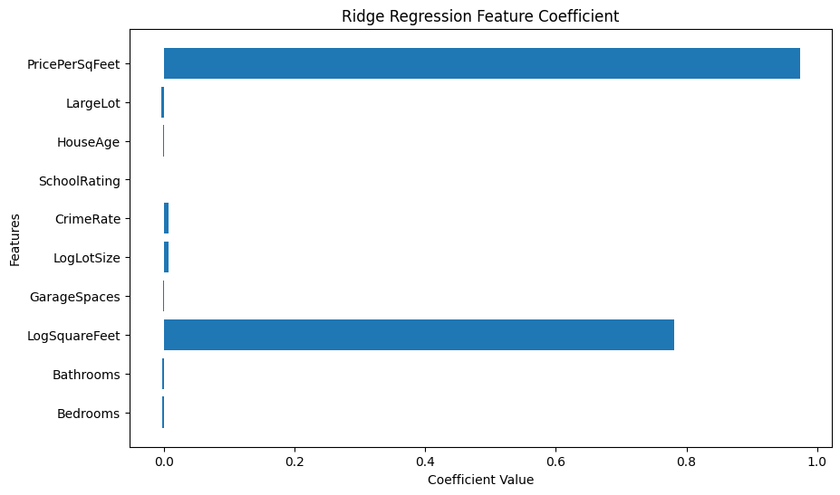

```python
import matplotlib.pyplot as plt

coef = ridge.coef_
features = X.columns
plt.figure(figsize=(10,6))
plt.barh(features,coef)
plt.title('Ridge Regression Feature Coefficient')
plt.xlabel('Coefficient Value')
plt.ylabel('Features')
plt.show()
```

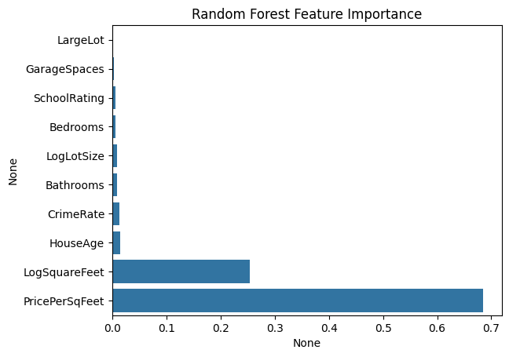

```python
# 2. Feature Importance (for tree-based models like Random Forest)

import pandas as pd
import seaborn as sns
from sklearn.ensemble import RandomForestRegressor


rf = RandomForestRegressor(n_estimators = 100, random_state=42)
rf.fit(X,y)


importances = rf.feature_importances_
feat_imp = pd.Series(importances, index=X.columns).sort_values()
sns.barplot(x=feat_imp, y=feat_imp.index)
plt.title('Random Forest Feature Importance')
plt.show()
```

# Now, If again, to reintroduce zipcode variable, which exluded due to model failures , if include it again , how does it affect the model , let's check out, if the model affects by location too

```python
#  To encode zipcode, group it :

zip_avg_price = df.groupby('ZipCode')['LogPrice'].mean()
df['ZipValue'] = df['ZipCode'].map(zip_avg_price)
print(df.head())
```

```
   Bedrooms  Bathrooms  YearBuilt  GarageSpaces  ZipCode  CrimeRate  \
0         1        1.9       1979             2    82240      48.60
1         2        2.0       1987             2    74315      92.03
2         1        3.0       1982             1    79249      52.08
3         3        3.3       1907             3    80587      61.65
4         4        3.4       1994             2    20756      15.66

   SchoolRating  HouseAge   LogPrice  LogSquareFeet  LogLotSize  \
0             5        46  12.310243       8.481980    0.371564
1             9        38  13.555645       6.942157    0.559616
2             3        43  12.354200       7.926242    0.378436
3             1       118  13.051593       7.903966    0.482426
4             4        31  12.791573       7.069023   -0.301105

   PricePerSqFeet  LargeLot   ZipValue
0        1.451341         1  12.310243
1        1.952656         1  13.555645
2        1.558645         1  12.354200
3        1.651272         1  13.051593
4        1.809525         0  12.791573
```

```python
import pandas as pd
from sklearn.model_selection import train_test_split
from sklearn.linear_model import Ridge, Lasso
from sklearn.metrics import mean_squared_error
from sklearn.preprocessing import StandardScaler

# Define feature and target variables

X = df[['Bedrooms', 'Bathrooms','ZipValue', 'LogSquareFeet','GarageSpaces','LogLotSize','CrimeRate','SchoolRating','HouseAge','LargeLot', 'PricePerSqFeet']]
y = df['LogPrice']

#split the data into training and testing set
X_train,X_test,y_train,y_test = train_test_split(X,y, test_size=0.2, random_state=42)


#It's often good to scale the features for ridge and lasso regulaztions
scaler = StandardScaler()
X_train_scaled = scaler.fit_transform(X_train)   # fir on training data, transform it
X_test_scaled = scaler.transform(X_test)        #only transform test data

#ridge regression

ridge = Ridge(alpha=1.0)   #regulaztion strength (you can change alpha to adjust)
ridge.fit(X_train_scaled, y_train)
y_pred_ridge = ridge.predict(X_test_scaled)

#evaluate Ridge expression


ridge_score = ridge.score(X_test_scaled, y_test)    #r2 score
ridge_mse = mean_squared_error(y_test, y_pred_ridge)

#  Lasso regressiomn--

lasso = Lasso(alpha=0.1)
lasso.fit(X_train_scaled, y_train)
y_pred_lasso = lasso.predict(X_test_scaled)


#evaluate lasso regression
lasso_score = lasso.score(X_test_scaled, y_test)
lasso_mse = mean_squared_error(y_test, y_pred_lasso)

# print results for comaprison
print('Ridge Rgression R2:', ridge_score)
print('Ridge regression MSe', ridge_mse)
print('Lasso Regression', lasso_score)
print('Lasso regression MSE', lasso_mse)


# compare coeffcients to see wha feature sare important
print('Ridge Regression Coff:', ridge.coef_)
print('Lasso regression Coeff', lasso.coef_)
```

```
Ridge Rgression R2: 0.9998277199616539
Ridge regression MSe 5.025354773699381e-05
Lasso Regression 0.9677452287495462
Lasso regression MSE 0.009408615776624987
Ridge Regression Coff: [-2.57846374e-04 -2.76385636e-04  5.09403557e-01  9.51569162e-02
 -1.55212455e-04  8.26196773e-04  9.70676803e-04 -9.95817542e-06
 -6.27010432e-05 -4.35540116e-04  1.18543947e-01]
Lasso regression Coeff [ 0.          0.          0.48003263 -0.          0.         -0.
 -0.          0.          0.         -0.          0.        ]
```

```python
# What "RIDGE" SAYS:
 ## ZipValue: 0.509 – Massive impact (location-based)

## -LogSquareFeet: 0.095 – Strong influence (size)

##  -PricePerSqFeet: 0.118 – Also large (value/density)

##  -LogLotSize / CrimeRate: small but non-zero positive

##   -Others are near-zero → minimal effect

# what "lasso' says:
## Lasso completely zeroed out everything except:

#  - ZipValue: 0.48

##  -That’s a very loud signal — Lasso is saying:

##  -“I only need ZipValue to make strong predictions — everything else adds little value once I have that.”
```

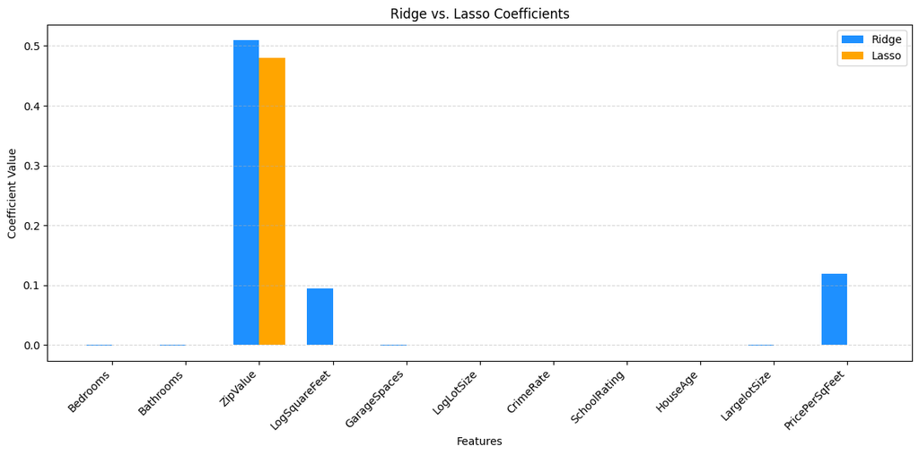

```python
import pandas as pd
import numpy as np
import matplotlib.pyplot as plt

# features

features = ['Bedrooms','Bathrooms','ZipValue','LogSquareFeet','GarageSpaces','LogLotSize','CrimeRate','SchoolRating','HouseAge','LargelotSize','PricePerSqFeet']

#coefficients from your model outpputs

ridge_coeffs = [-2.578e-04, -2.763e-04, 0.5094, 0.0951,
                -1.552e-04, 8.261e-04, 9.707e-04, -9.958e-06,
                -6.270e-05, -4.355e-04, 0.1185]

lasso_coeffs = [0, 0, 0.4800, 0, 0, 0, 0, 0, 0, 0, 0]

#create a Data Frame

coef_df = pd.DataFrame({
    'Feature':features,
    'Ridge':ridge_coeffs,
    'Lasso':lasso_coeffs
})

#plot

plt.figure(figsize=(12,6))
bar_width = 0.35
index = np.arange(len(features))


plt.bar(index, coef_df['Ridge'], bar_width, label='Ridge', color = 'dodgerblue')
plt.bar(index + bar_width, coef_df['Lasso'], bar_width, label='Lasso', color='orange')

plt.xlabel('Features')
plt.ylabel('Coefficient Value')
plt.title('Ridge vs. Lasso Coefficients')
plt.xticks(index + bar_width / 2, features, rotation=45, ha='right')
plt.legend()
plt.tight_layout()
plt.grid(axis='y', linestyle='--', alpha=0.5)
plt.show()
```

# This will make it very clear how Lasso aggressively regularizes and selects features, while Ridge distributes weight more broadly.

# CONCLUSION:

## -This approach can be a valuable framework for future real estate modeling tasks or similar domains where raw correlations may be misleading.